# Bivariate Regression and OLS

EC325: Econometrics

Prof. Caraher

Colby College

Last updated: 10-05-2026

# From RCTs to Regression

## Where We’ve Been

- In Unit 3, we learned that **Randomized Control Trials** provide the gold standard for causal inference
- Random assignment eliminates selection bias: the simple difference in means equals the causal effect

## Where We’re Going

- But most economic questions **cannot** be answered with experiments
- Why?
  - We typically work with **observational data** where treatment is not randomly assigned
  - There may be ethical issues involved (i.e., is it ethical to withhold insurance from the control group?)
  - Some research questions we are interested in rule out this possibility (e.g., economic history)
  - Social science experiments are expensive!
- Instead, we need to develop tools which **may** recover similar causal estimates without an RCT
- The workhorse behind all these methods: **Ordinary Least Squares (OLS)**
- This unit will focus on **bivariate OLS regression**

# Modeling Relationships Between Variables

## What Do We Mean by “Relationship”?

- Before we move onto regression, let’s take a set back
- Suppose we have two variables, $y$ and $x$
- We want to study “how $x$ is related to $y$”
- What does this really mean?
- We need a precise, mathematical way to do this
- The most natural approach: what is the **average** value of $y$ for each different value of $x$?

## Conditional Expectations

- This idea is operationalize as the **conditional expectation**

$$E[Y | X = x]$$

- “If we knew that $X$ took on some specific value $x$, what would we expect $Y$ to be, **on average**?”
- (Recall some of the notation from the Potential Outcomes framework, e.g. $E[Y_{1i} | D_i = 1]$)
- More specifically, we are interested in *changes* in this conditional expectation of $Y$ as $X$ varies, i.e,:

$$E[Y | X = x_1] - E[Y | X = x_0]$$

## Example: Education and Wages

- $X$ = education level (HS degree, College degree, Professional degree)
- $Y$ = hourly wage
- For each education level, compute the average wage $E[wage | educ = \{HS deg, Coll deg, Pof deg\}]$ among people in a given education group

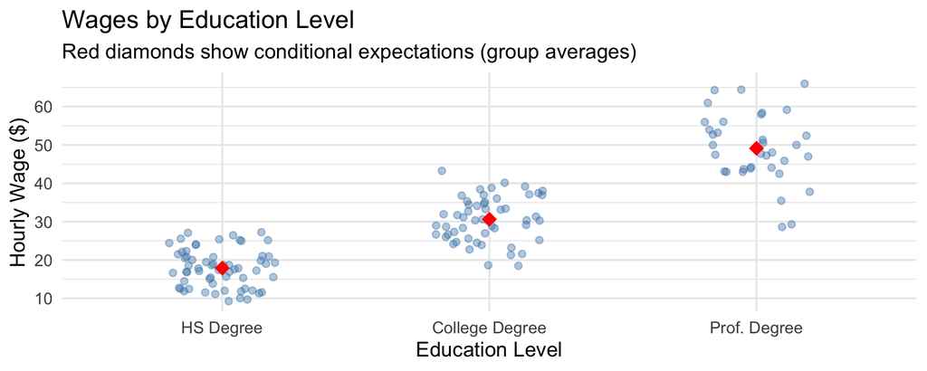

## What Do We See?

- Each blue dot is an individual education level plotted against their wage
- The **red diamonds** show the conditional expectations: $E[Y|X=\text{HS}]$, $E[Y|X=\text{College}]$, $E[Y|X=\text{Prof}]$
- Together, these group-specific averages tell us how wages **change** as education increases
- This is precisely what we want to estimate!

# Visualizing Relationships: Scatter Plots

## Why Scatter Plots?

- When both $x$ and $y$ are **continuous**, a scatter plot is the best way to visualize their relationship
- Each point represents one observation: its $x$ value and its $y$ value
- Scatter plots help us:
  - See the **direction** of a relationship (positive or negative)
  - Identify **outliers** or unusual patterns
  - Judge whether a **linear** model is appropriate

## Introduction to `ggplot2`

- We’ll use the `ggplot2` package (part of the `tidyverse`) for all our visualizations
- `ggplot2` builds plots **layer by layer** – you start with data, then add visual elements on top:
1. **Start with data:** `ggplot(data = your_data)` – creates an empty canvas
2. **Add a geometry:** `+ geom_point(...)` for scatter plots, `+ geom_histogram(...)` for histograms, etc.
3. **Map variables to aesthetics:** inside `aes()`, tell R which columns go on each axis (and optionally `color`, `size`, `shape`, etc.)
4. **Polish:** add labels with `labs()` and a clean theme with `theme_minimal()`

**Want More?**

The Unit 2 lecture notes cover `ggplot2` in much more detail, including histograms, bar charts, and more customization options. Refer back to those as needed!

## Building a Scatter Plot

- Let’s build a scatter plot step by step!
- Start by “initializing” our plot by specifying our data with the `ggplot()` function
- We will use the `mtcars` data. Say we want to see the relationship between horsepower (`hp`) and miles per gallon (`mpg`)
- Need the `tidyverse` to use `ggplot()`!

```r
library(tidyverse)

ggplot(data = mtcars)
```

## Building a Scatter Plot

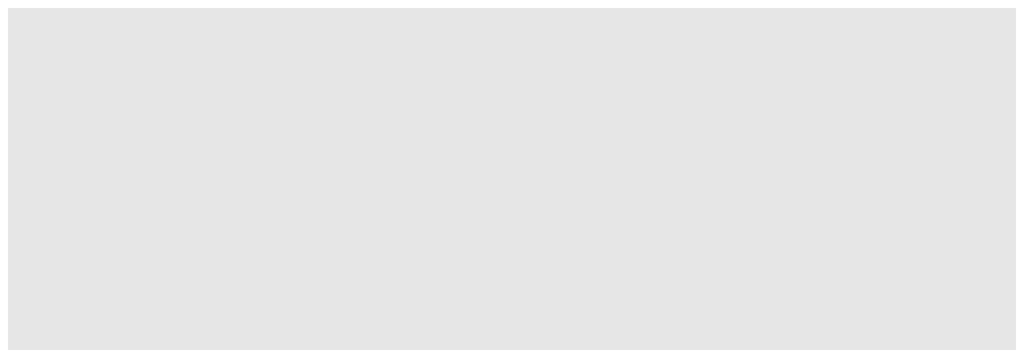

## Building a Scatter Plot

- We just have an empty square!
- Why? We did not yet tell R:
  - 1. which geometry we want to use, and
  - 2. how we want to map variables in our data to the aesthetics of that geometry
- In this case, we want **scatterplot** geometry (`geom_point()`) and we want to map horsepower `hp` to the x-axis and `mpg` to the y-axis
- We can do so by adding (`+`) to our initial plot the `geom_point()` function, and within that the `aes()` function

```r
ggplot(data = mtcars) +
  geom_point(aes(x = hp, y = mpg))
```

## Building a Scatter Plot

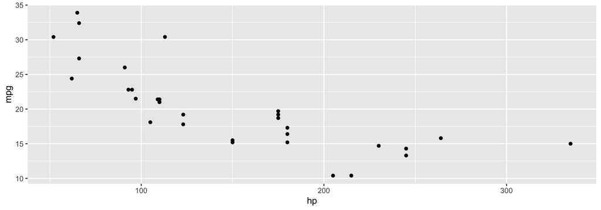

## Adding Other Geometries

- `ggplot()` allows us to add additional geometries and aesthetics with the plus sign `+`
- Let’s say we want to add a line of best fit to the data (i.e., a trend line)
- We can do so by adding the `geom_smooth()` geometry, with the same aseptic mapping to the x and y inputs
- But in addition to the aesthetic mapping from variables in the data to elements of the geometry, we also need to sometimes supply additional arguments to the geometry functions
- In the case of `geom_smooth()`, we need to tell it the shape of the line (`lm`) and to omit uncertainty estimates

```r
ggplot(data = mtcars) +
  geom_point(aes(x = hp, y = mpg)) +
  geom_smooth(aes(x = hp, y = mpg), method = "lm", se = FALSE)
```

## Adding Other Geometries

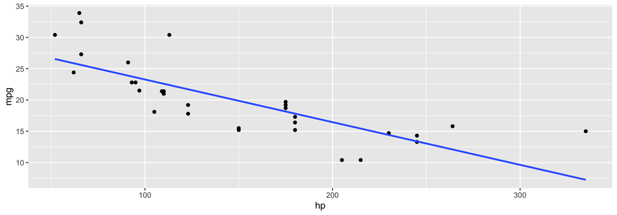

## Making Publication-Quality Plots

- Always add proper labels and titles using the `labs()` function after another `+`
- Each aesthetic can get its own label (e.g., x, y, title, subtitle, etc.)
- We cab also get rid of the grey-square background and get nicer-looking figure by adding `theme_minimal()` (there are other pre-packaged themes out there too)

```r
ggplot(data = mtcars) +
  geom_point(aes(x = hp, y = mpg)) +
  geom_smooth(aes(x = hp, y = mpg), method = "lm", se = FALSE) +
  labs(
    title = "Fuel Efficiency vs. Engine Power",
    x = "Horsepower",
    y = "Miles per Gallon",
  ) +
  theme_minimal()
```

## Making Publication-Quality Plots

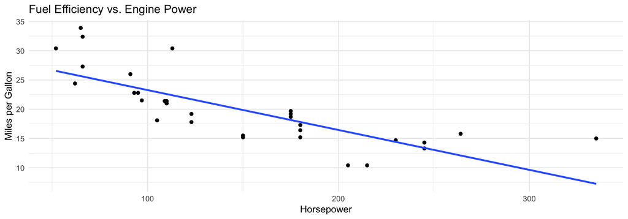

# The Population Regression Model

## Writing Down the Population Model

- We start by assuming that there exists a **true relationship** between $x$ and $y$ in the population – even though we can’t observe it directly
- **Population** = everyone we want to learn about (e.g., all U.S. workers). Our data are usually a **sample** drawn from it.
- The **bivariate, linear regression model** is written as follows:

$$y = \beta_0 + \beta_1 x + \mu$$

where:

- $y$ is the **dependent variable** (outcome)
- $x$ is the **independent variable** (explanatory)
- $\mu$ is the **error term** (everything else that affects $y$)
- $\beta_0$ and $\beta_1$ are **true population parameters which relate $x$ to $y$** (unknown)

## The Error Term

- The error term $\mu$ is crucial – it captures **everything** that affects $y$ other than $x$
- In a wage equation: $wage = \beta_0 + \beta_1 \cdot educ + \mu$
- $\mu$ might include:
  - Innate ability
  - Motivation
  - Family connections
  - Luck
  - Work experience

## Back to Conditional Expectations

- How does the regression model link back to our study of the “relationship between two variables”?
- Recall our mathematical definition: How does $E[Y | X = x]$ change as $x$ changes?
- Average the model $y = \beta_0 + \beta_1 x + \mu$ among people with the same $educ$ (i..e, expectation of $y$ conditional on $x$)
- Only $\mu$ varies within that group, so all other terms will be pulled out of the expectations operator (see expectations properties)

$$\begin{aligned}
wage &= \beta_0 + \beta_1 \cdot educ + \mu \\[4pt]
E[wage \mid educ] &= E[(\beta_0 + \beta_1 \cdot educ + \mu) \mid educ] \\[4pt]
&= \beta_0 + \beta_1 \cdot educ + E[\mu \mid educ] \\[4pt]
&= \beta_0 + \beta_1 \cdot educ \qquad \text{if } E[\mu \mid educ] = 0
\end{aligned}$$

- A point on regression line *is* the conditional expectation of $Y$ for some $X = x$!

## Interpreting $\beta_1$: The Slope

- Since the regression line is in the form $y = mx + b$, then $\beta_1$ describes the **slope** of the regression line
- In our context, it tells us how much $y$ will change **on average** when $x$ increases by 1
- Since our regression line is **linear**, the slope will be constant no matter the value of $x$
- How can we see this more clearly? Pick **any** education level $e$ and compare group averages one year apart:

$$\begin{aligned}
E[wage \mid educ = e+1] - E[wage \mid educ = e]
&= [\beta_0 + \beta_1 (e+1)] - [\beta_0 + \beta_1 e] \\[2pt]
&= \beta_0 + \beta_1 e + \beta_1 - \beta_0 - \beta_1 e \\[2pt]
&= \beta_1
\end{aligned}$$

## Interpreting $\beta_0$: The Intercept

- In $y = mx + b$ form, $\beta_0$ is the **intercept**: the height of the line when $x = 0$
- In our context, plug in $educ = 0$:

$$E[wage \mid educ = 0] = \beta_0 + \beta_1 \cdot 0 = \beta_0$$

- So $\beta_0$ is the **average wage for people with zero years of education**
- Rarely meaningful on its own: almost no one has 0 years of school, so the line is **extrapolating** beyond the data. E.g., if $E[wage \mid educ] = -10 + 2.50 \cdot educ$, then $\beta_0 = -\$10$, a negative wage!
- Its main job is to set the **height** of the line

# From Population to Sample

## We Can’t See the Population

- The population model $y = \beta_0 + \beta_1 x + \mu$ describes the **true** relationship present in the **population**
- But $\beta_0$ and $\beta_1$ are **unknown** – we never observe the whole population
- Instead, we use our **sample** to compute **estimates** of these parameters, which we write with “hats”:
- $\hat{\beta}_0$ = our estimate of $\beta_0$
- $\hat{\beta}_1$ = our estimate of $\beta_1$

## Predicted Values and the Fitted Line

- Using our estimates (we will talk about where they come from in a bit), we construct the **regression line**:

$$\hat{y} = \hat{\beta}_0 + \hat{\beta}_1 x$$

- For any value of $x$, this gives us $\hat{y}$, the **predicted value** of $y$

## Residuals: The Prediction Errors

- Our predictions won’t be perfect. The **residual** $ for observation $i$ is:

$$\underbrace{\hat{\mu}_i}_{\text{residual}}
= \underbrace{y_i}_{\text{actual value}}
- \underbrace{\hat{y}_i}_{\text{predicted value}}
= y_i - \underbrace{(\hat{\beta}_0 + \hat{\beta}_1 x_i)}_{\text{point at fitted line at } x_i}$$

- Positive residual: we **underpredicted** (actual > predicted)
- Negative residual: we **overpredicted** (actual < predicted)

## Visualizing Residuals

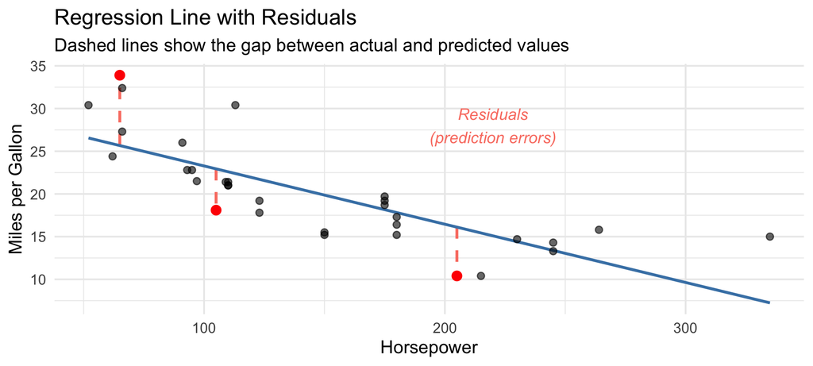

## The Goal: Minimize the Residuals

- So where do we get our $\hat{\beta}$ estimates?
- We get them by drawing the **best line through the data as possible**
- And how do we do that?
- We want to make residuals as small as possible
- Can’t just minimize $\sum \hat{\mu}_i$ since positive and negative residuals would cancel out!
- Instead, minimize the **Sum of Squared Residuals (SSR)**:

$$SSR = \sum_{i=1}^{n} \hat{\mu}_i^2 = \sum_{i=1}^{n} (y_i - \hat{\beta}_0 - \hat{\beta}_1 x_i)^2$$

- This is where the name **“Ordinary Least Squares”** comes from!

# The OLS Estimator

## The Minimization Problem

- Given $n$ observations $\{(x_i, y_i): i = 1, ..., n\}$, find $\hat{\beta}_0$ and $\hat{\beta}_1$ that minimize:

$$\min_{\hat{\beta}_0, \hat{\beta}_1} \sum_{i=1}^{n} (y_i - \hat{\beta}_0 - \hat{\beta}_1 x_i)^2$$

- This is a calculus optimization problem – take partial derivatives, set equal to zero, solve

**Full Derivation**

The step-by-step derivation using first-order conditions is in Section 4.4 of the lecture notes. We’ll skip the algebra here and focus on the **result** and its **intuition**.

## The OLS Formulas

- Solving the minimization problem gives us:

**The OLS Slope**

$$\hat{\beta}_1 = \frac{\sum_{i=1}^{n}(x_i - \bar{x})(y_i - \bar{y})}{\sum_{i=1}^{n}(x_i - \bar{x})^2} = \frac{Cov(x, y)}{Var(x)}$$

**Important**

**The OLS Intercept:**

$$\hat{\beta}_0 = \bar{y} - \hat{\beta}_1 \bar{x}$$

- The regression line always passes through the point $(\bar{x}, \bar{y})$ – the “center” of the data!

## An Important Observation

- The slope $\hat{\beta_1}$ can also be written as:

$$\hat{\beta}_1 = \rho_{xy} \frac{\sigma_y}{\sigma_x}$$

where $\rho_{xy}$ is the **correlation** between $x$ and $y$ and $\sigma_y$, $\sigma_x$ are the **standard deviations** of $x$ and $y$

- Bivariate OLS is essentially estimating a **(scaled) correlation** between $x$ and $y$
- And as we discussed in Unit 1: **correlation does not imply causation!**

## Visualizing OLS: Step 1 – The Data

Let’s build up the intuition for what OLS does, step by step.

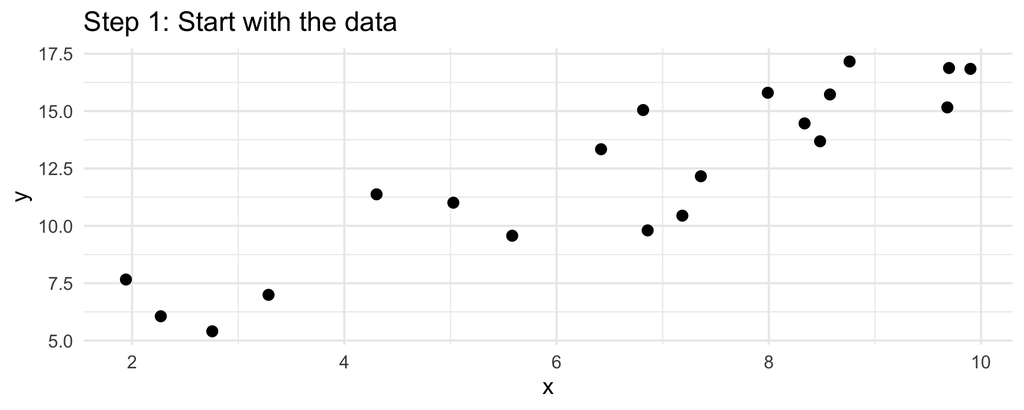

- We have 20 observations. How should we draw a line to summarize this relationship?

## Visualizing OLS: Step 2 – Try a Line

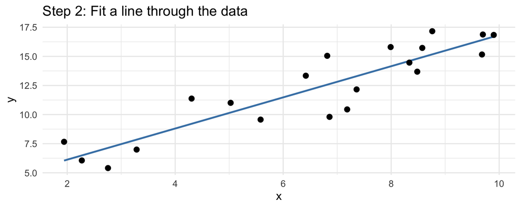

- The blue line could be any line, but we need to start somewhere to find the *best* one

## Visualizing OLS: Step 3 – One Residual

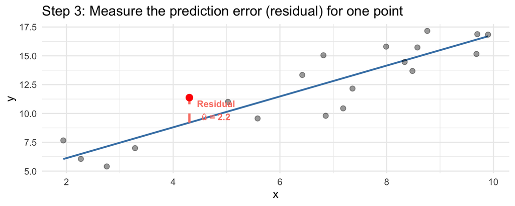

- The **residual** is the vertical distance between the point and the line

## Visualizing OLS: Step 4 – Square the Residual

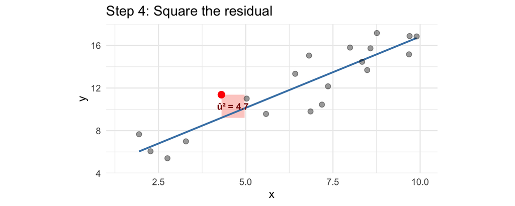

- We **square** the residual so that positive and negative errors don’t cancel

## Visualizing OLS: Step 5 – All Squared Residuals

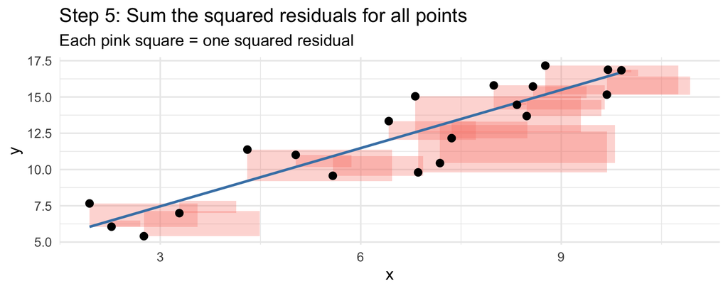

- Find the **total sum of squares**
- If it is not the smallest possible SSR you have found yet, draw a new line and try it again until you get the smallest!
- In reality, the calculus optimization techniques saves us from having to make multiple attempts at a regression line estimate and SSR
- The OLS formula chooses $\hat{\beta}_0$ and $\hat{\beta}_1$ to make the **total pink area** as small as possible!

# Computing OLS in R

## The `lm()` Function

- In R, the `lm()` function (“linear model”) performs OLS regression:

```r
# General syntax
my_lm <- lm(y ~ x, data = your_data)
```

- The formula `y ~ x` says: “$y$ is the dependent variable, $x$ is the independent variable”
- After you write the formula, include that `data =` argument after a comma and point it towards your dataframe object
- An **intercept** is included by default
- We usually save our regression output to an object so we can refer to it later (e.g., `my_lm <- lm(...)`)
- Use the `summary()` function on the `lm` object to access its stored estimates

## Example: MPG and Horsepower

- Let’s use the `mtcars` data to estimate the regression where our independent variable is `x = hp` and our dependent variable is `y = mpg`

```r
# Estimate the regression
lm_mpg <- lm(mpg ~ hp, data = mtcars)

# View the results
summary(lm_mpg)
```

```
Call:
lm(formula = mpg ~ hp, data = mtcars)

Residuals:
    Min      1Q  Median      3Q     Max
-5.7121 -2.1122 -0.8854  1.5819  8.2360

Coefficients:
            Estimate Std. Error t value Pr(>|t|)
(Intercept) 30.09886    1.63392  18.421  < 2e-16 ***
hp          -0.06823    0.01012  -6.742 1.79e-07 ***
---
Signif. codes:  0 '***' 0.001 '**' 0.01 '*' 0.05 '.' 0.1 ' ' 1

Residual standard error: 3.863 on 30 degrees of freedom
Multiple R-squared:  0.6024,    Adjusted R-squared:  0.5892
F-statistic: 45.46 on 1 and 30 DF,  p-value: 1.788e-07
```

## Reading the Output

- For now, focus only on the **`Estimate` column** (we will get to the others in future units)
  - The `(Intercept)` row is $\hat{\beta}_0$ and the `hp` row is $\hat{\beta}_1$
- So our fitted regression line is:

$$\widehat{mpg} = 30.10 - 0.068 \cdot hp$$

- $\hat{\beta}_0 = 30.10$: a car with **zero** horsepower is predicted to get 30.1 MPG (not meaningful here)
- $\hat{\beta}_1 = -0.068$: cars with one more horsepower get about **0.07 fewer miles per gallon**, on average (often useful to do this when interpreting estimates)
- One horsepower is tiny, so scale up: 100 more horsepower means $100 \times (-0.068) \approx$ **6.8 fewer MPG**, on average
- **Prediction:** a 150 hp car is predicted to get $30.10 - 0.068 \times 150 \approx 19.9$ MPG

## Visualizing the Regression Output

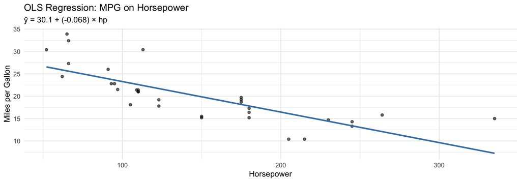

## Predicted Values and Residuals “By Hand”

- Sometimes we may want to refer to the values predicted by the regression line $\hat{y}_i$ (as opposed to the actual value of the $y_i$), as well as the residual $\hat{\mu}_i$
- We can do this two ways: “by hand” or with built-in functions
- Recall: $\hat{y}_i = \hat{\beta}_0 + \hat{\beta}_1 x_i$ and $\hat{\mu}_i = y_i - \hat{y}_i$
- `coef()` pulls the estimates out of our `lm` object; `mutate()` does the rest

```r
b0 <- coef(lm_mpg)[1]   # intercept
b1 <- coef(lm_mpg)[2]   # slope on hp

mtcars_hat <- mtcars |>
  select(mpg, hp) |>
  mutate(mpg_hat   = b0 + b1 * hp,     # predicted value
         mpg_resid = mpg - mpg_hat)    # residual

head(mtcars_hat)
```

```
                   mpg  hp  mpg_hat  mpg_resid
Mazda RX4         21.0 110 22.59375 -1.5937500
Mazda RX4 Wag     21.0 110 22.59375 -1.5937500
Datsun 710        22.8  93 23.75363 -0.9536307
Hornet 4 Drive    21.4 110 22.59375 -1.1937500
Hornet Sportabout 18.7 175 18.15891  0.5410881
Valiant           18.1 105 22.93489 -4.8348913
```

## Same Thing, Using Built-in Functions

- `predict()` returns the predicted values and `residuals()` returns the residuals, straight from the `lm` object

```r
mtcars_hat <- mtcars_hat |>
  mutate(mpg_hat2   = predict(lm_mpg),     # predicted value
         mpg_resid2 = residuals(lm_mpg))   # residual

head(mtcars_hat)
```

```
                   mpg  hp  mpg_hat  mpg_resid mpg_hat2 mpg_resid2
Mazda RX4         21.0 110 22.59375 -1.5937500 22.59375 -1.5937500
Mazda RX4 Wag     21.0 110 22.59375 -1.5937500 22.59375 -1.5937500
Datsun 710        22.8  93 23.75363 -0.9536307 23.75363 -0.9536307
Hornet 4 Drive    21.4 110 22.59375 -1.1937500 22.59375 -1.1937500
Hornet Sportabout 18.7 175 18.15891  0.5410881 18.15891  0.5410881
Valiant           18.1 105 22.93489 -4.8348913 22.93489 -4.8348913
```

- Identical to what we computed by hand!

## Predicting at New Values of $x$

- The `newdata` argument lets `predict()` compute $\hat{y}$ at **any** value of $x$, even ones not in our data
- What MPG do we predict for a car with 150 horsepower?

```r
predict(lm_mpg, newdata = data.frame(hp = 150))
```

```
       1
19.86462
```

- Same as our calculation from before: $30.10 - 0.068 \times 150 \approx 19.9$
- `newdata` must be a data frame with a column named exactly like the $x$ variable (here, `hp`)
- Tip for missing data: `lm()` drops rows with missing values, so `predict(lm_mpg)` and `residuals(lm_mpg)` come back too short for `mutate()`. `predict(lm_mpg, newdata = mtcars)` returns a value for every row (`NA` where `hp` is missing)

# Goodness-of-Fit: R-Squared

## How Well Does Our Line Fit?

- **R-squared** ($R^2$): the fraction of the **total variation** in $y$ explained by the regression

$$R^2 = 1 - \frac{SSR}{SST} = \frac{SST - SSR}{SST} = \frac{\text{explained variation}}{\text{total variation}}$$

where:

- $SST = \sum(y_i - \bar{y})^2$ = **total** variation in $y$ (how spread out $y$ is around its mean)
- $SSR = \sum\hat{\mu}_i^2$ = **unexplained** variation (what’s left over, i.e., the residuals)
- $R^2$ is always between 0 and 1:
  - $R^2 = 0$: $x$ explains none of the variation in $y$ (a flat line, $\hat{\beta}_1 = 0$)
  - $R^2 = 1$: $x$ explains all of it (every point is exactly on the line)
- `mpg` on `hp`: $R^2 = 0.60$ (`Multiple R-squared` in `summary()`), so horsepower explains about **60%** of the variation in MPG

## R-Squared: Regression with little explanatory power

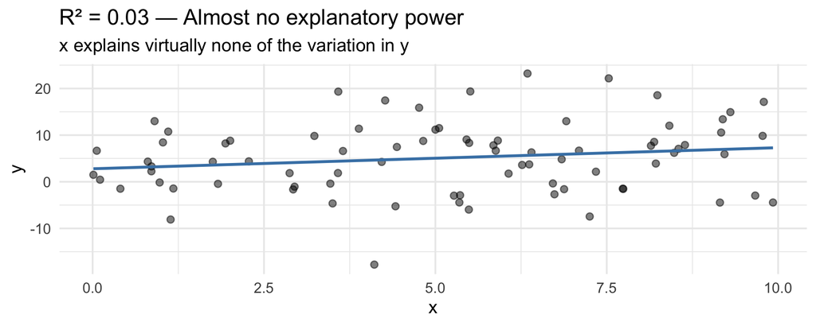

- The data is a **cloud** – knowing $x$ barely helps predict $y$

## R-Squared: Moderate Fit

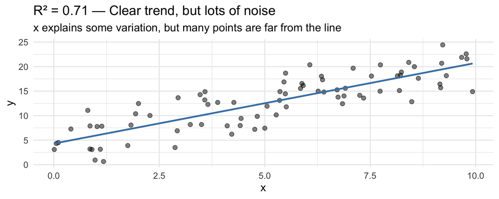

- A clear **upward trend**, but individual predictions would be imprecise

## R-Squared: Near-Perfect Fit

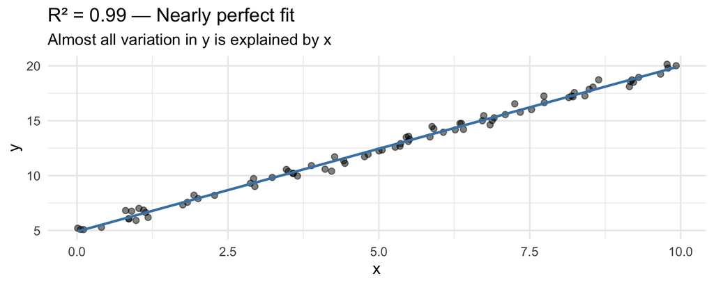

- Points hug the line tightly – $x$ explains almost everything about $y$

## Caution About R-Squared

**Don’t Over-Interpret R-Squared**

- A **high** $R^2$ does NOT mean we have a causal estimate – it just means $x$ is highly correlated with $y$ and we do a good job explaining to total variation in $y$
- A **low** $R^2$ does NOT mean our estimate is wrong or unimportant - sometimes, we may not be interested in explaining **all** variation in $y$, but rather a subset of it
- In cross-sectional data, $R^2$ values of 0.1 to 0.3 are common and can still represent economically meaningful relationships

# What Makes a Good Estimator?

## Can We Trust Our Estimates?

- We now know how to compute $\hat{\beta}_0$ and $\hat{\beta}_1$ – but should we trust the numbers?
- Remember: population parameters ($\beta$) are fixed, but *different samples give different estimates* ($\hat{\beta}$)
- The property we want is **unbiasedness**: on average, our estimates hit the target

**Unbiasedness**

$E[\hat{\beta}_1] = \beta_1$ — no systematic tendency to over- or under-estimate. Individual shots miss, but the **center** of all shots lands on the bullseye.

- The key question: **under what conditions** is OLS unbiased? That depends on **assumptions**.

# The Gauss-Markov Assumptions

## Assumptions 1–3: The “Mechanical” Requirements

These first three assumptions are relatively easy to check. See the lecture notes for details and examples.

| Assumption | What it says | In plain English |
| --- | --- | --- |
| 1. Linear in parameters | $y = \beta_0 + \beta_1 x + \mu$ | The model is linear in the $\beta$’s (not necessarily in $x$!) |
| 2. Random sampling | Obs. are i.i.d. draws | Our sample is representative of the population |
| 3. Variation in $x$ | $\sum(x_i - \bar{x})^2 > 0$ | $x$ isn’t the same value for everyone |

- These are usually satisfied in practice – the **hard** assumption is next

## Assumption 4: Zero Conditional Mean

$$E[\mu | x] = 0$$

**The Most Important Assumption**

The average value of all unobserved factors affecting $y$ is the **same** regardless of the value of $x$.

## What Does “Zero Conditional Mean” Mean?

- In words: $E[\mu | x] = 0$ means the **error term is unrelated to** $x$
- For *every* possible value of $x$, the average of all unobserved factors is zero
- Think of it this way: if you could gather all people with $x = 10$ and average their $\mu$ values, you’d get zero. Same for $x = 20$. Same for any $x$.

## Visualizing the Zero Conditional Mean

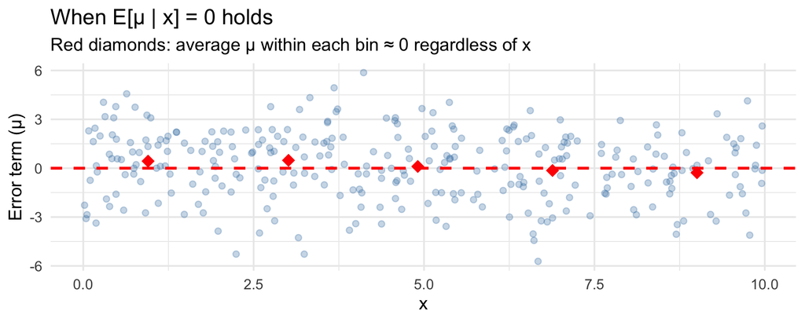

- No matter where we look along the x-axis, errors average to **zero**

## When the Zero Conditional Mean Fails

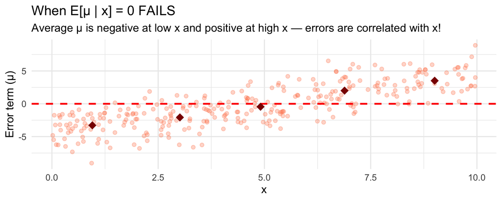

- The average error **rises** with $x$ – the error is correlated with our independent variable

## Why Does This Matter for Wages?

- Consider the wage equation: $wage = \beta_0 + \beta_1 \cdot educ + \mu$
- For $E[\mu | educ] = 0$ we need:
- Among people with 8 years of education: average $\mu$ = 0
- Among people with 12 years of education: average $\mu$ = 0
- Among people with 16 years of education: average $\mu$ = 0
- Is this plausible?
- People with more education tend to have higher **ability** (which is in $\mu$)
- So $E[\mu | educ = 16] > E[\mu | educ = 8]$ – the assumption **fails**
- This is the fundamental challenge of causal inference with observational data!

## Summary: The Four Assumptions for Unbiasedness

| Assumption | What it says |
| --- | --- |
| 1. Linear in parameters | $y = \beta_0 + \beta_1 x + \mu$ |
| 2. Random sampling | Observations are independent draws |
| 3. Variation in $x$ | $\sum(x_i - \bar{x})^2 > 0$ |
| **4. Zero conditional mean** | $E[\mu \\| x] = 0$ |

- Under these four assumptions, **OLS is unbiased**: $E[\hat{\beta}_1] = \beta_1$

# Seeing Unbiasedness in Action

## Simulating Unbiasedness

Let’s prove unbiasedness to ourselves! First, create a “population” with **known** parameters:

```r
set.seed(1248)
n_pop <- 1000
pop_data <- tibble(
  x = sample(1:100, size = n_pop, replace = TRUE),
  y = 3.5 + 2.21 * x + rnorm(n_pop)
)

# The TRUE slope is 2.21
```

## Drawing Many Samples

Now draw 500 random samples and estimate $\hat{\beta}_1$ each time. We use a `for()` loop to repeat the same set of steps a fixed number of times. The loop runs the code inside `{}` once for each value of `i` (from 1 to 500), so we don’t have to copy and paste the same code 500 times:

```r
set.seed(812476)
n_sims <- 500
sample_size <- 25

# Create a dataframe to store our results
sim_results <- tibble(iteration = integer(), b1_hat = numeric())

# Run the simulation
for (i in 1:n_sims) {
  samp <- slice_sample(pop_data, n = sample_size, replace = TRUE)
  b1_hat <- coef(lm(y ~ x, data = samp))[2]
  sim_results <- sim_results |> add_row(iteration = i, b1_hat = b1_hat)
}

mean(sim_results$b1_hat)
```

```
[1] 2.208528
```

# So What? Bias, OVB, and Causality

## When Assumption 4 Fails

- When $E[\mu | x] = 0$: $\hat{\beta}_1$ is an unbiased estimate of the **causal effect**
- When $E[\mu | x] \neq 0$: OLS is **biased** – $\hat{\beta}_1$ picks up the causal effect *plus* whatever in $\mu$ moves with $x$
  - Why it fails: if **some factor in $\mu$ is correlated with $x$**, the average of $\mu$ changes as $x$ changes – that is exactly $E[\mu | x] \neq 0$
  - Education example: average **ability** (in $\mu$) rises with education, so a component of the error term $\mu$ is correlated with $x$

## Omitted Variable Bias

- The most common case is **omitted variable bias**: a variable that belongs in the model is left out (so it sits in $\mu$) AND is correlated with $x$, so our slope picks up the effect of both
  - Example: estimating the return to education while omitting ability → $\hat{\beta}_1$ **overstates** the causal effect
  - Remember from Unit 3: this is essentially **selection bias** – people who choose more education also tend to have higher ability

**Correlation vs. Causation**

OLS always estimates *something*. Whether that something is a **causal effect** or merely a **correlation** depends entirely on whether the assumptions hold. Most of econometrics is about finding clever ways to make the zero conditional mean assumption more plausible.

# Variance, Standard Errors, and BLUE

## Beyond Unbiasedness

- Unbiasedness tells us OLS is “right on average” – but individual estimates can vary a lot
- We also care about **precision**: how much do estimates bounce around from sample to sample?
- This is measured by the **variance** of the OLS estimator
  - It asks: how much does our estimate $\hat{\beta}_1$ change if we draw a *different* sample?
  - Formally, $Var(\hat{\beta}_1) = E[(\hat{\beta}_1 - E[\hat{\beta}_1])^2]$ – the average squared distance of $\hat{\beta}_1$ from its mean
- We saw this in our simulation: the 500 estimates were centered near 2.21, but individual estimates ranged from 2.18 to 2.23. That **spread** is what the variance measures
- Why it matters: in practice we only get **one** sample. The lower the variance, the more likely our one estimate is close to $\beta_1$

## Assumption 5: Homoskedasticity

- To derive the variance of OLS, we need one more assumption:

$$Var(\mu | x) = \sigma^2$$

- The “spread” of errors is **constant** across all values of $x$

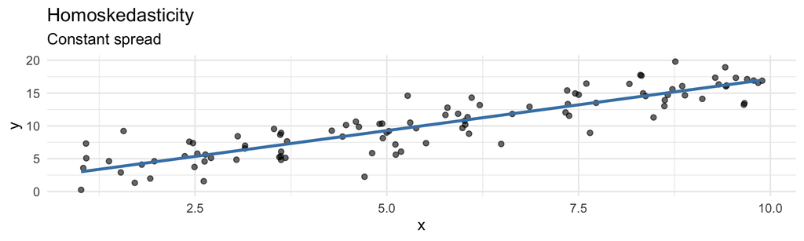

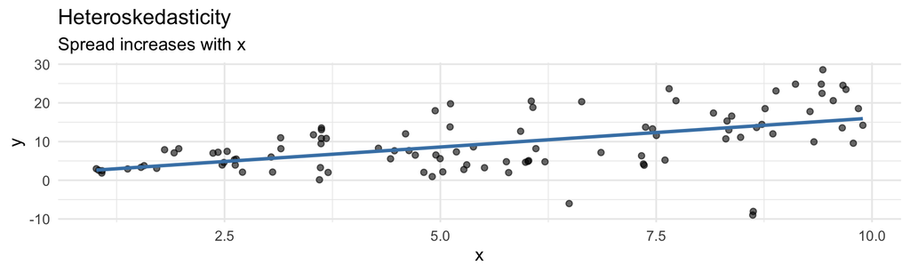

## The Variance of $\hat{\beta}_1$

- Start from the slope formula. Using the fact that $y_i = \beta_0 + \beta_1 x_i + \mu_i$:

$$\hat{\beta}_1 = \beta_1 + \frac{\sum(x_i - \bar{x})\mu_i}{\sum(x_i - \bar{x})^2}$$

- The only random piece is $\mu_i$. Since the $\mu_i$ are independent (random sampling) with constant variance $\sigma^2$ (homoskedasticity):

**Variance of the OLS Slope**

$$Var(\hat{\beta}_1) = \frac{\sigma^2}{SST_x}$$

where $\sigma^2 = Var(\mu)$ is the error variance and $SST_x = \sum(x_i - \bar{x})^2$ is the total variation in $x$.

**Full Derivation**

The step-by-step derivation is in Section 4.10 of the lecture notes.

## What Affects Precision?

$$Var(\hat{\beta}_1) = \frac{\sigma^2}{SST_x}$$

- **More noise** ($\sigma^2$ ↑) → **less** precise estimates
- **More variation in $x$** ($SST_x$ ↑) → **more** precise estimates
- **Larger samples** ($n$ ↑) → **more** precise estimates, since each observation adds to $SST_x$

## What Affects Precision? Simulations

Each histogram shows 500 OLS estimates of $\beta_1$. Red dashed line: the true value, $\beta_1 = 2$.

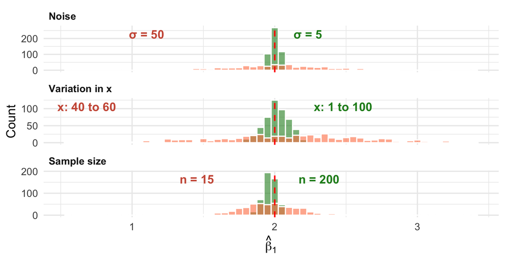

## Standard Errors

- The standard deviation of $\hat{\beta}_1$ is $\sqrt{Var(\hat{\beta}_1)} = \sigma / \sqrt{SST_x}$, but we don’t know $\sigma$
- The **standard error** replaces $\sigma$ with $\hat{\sigma}$, its estimate from the squared sum of residuals, SSR:

$$se(\hat{\beta}_1) = \frac{\hat{\sigma}}{\sqrt{SST_x}}$$

- where $\hat{\sigma} = \sqrt{SSR/(n-2)}$ (more on this next unit!)

## OLS is BLUE

**BLUE: Best Linear Unbiased Estimator**

**Best** means OLS has the **lowest variance** of all linear unbiased estimators.

| Assumption | Needed for Unbiasedness? | Needed for BLUE? |
| --- | --- | --- |
| 1. Linear in parameters | Yes | Yes |
| 2. Random sampling | Yes | Yes |
| 3. Variation in $x$ | Yes | Yes |
| **4. Zero conditional mean** | **Yes** | Yes |
| 5. Homoskedasticity | No | **Yes** |

- Assumptions 1-4 → OLS is **unbiased**
- All five → OLS is **BLUE**

## Implications of a BLUE Estimator

- **OLS is the default choice**: when all five assumptions hold, it is not mathmatically possible to derive a more precise estimator
- **“Best” doesn’t mean “precise”**: with a lot of noise, little variation in $x$, or a small sample, even OLS estimates can be imprecise (though still better than next alternative)

# Interpretation Practice Exercises

## Practice 1: Studying and Exam Scores

A professor collects data on how many hours her students studied for an exam and estimates:

$$\widehat{score} = 60 + 5 \cdot hours, \qquad R^2 = 0.20$$

where $score$ is the exam score (out of 100) and $hours$ is hours spent studying

1. Interpret the slope, $\hat{\beta}_1 = 5$
2. Interpret the intercept, $\hat{\beta}_0 = 60$
3. What is the predicted score for a student who studies 4 hours?
4. Interpret the $R^2$

## Practice 1: Answers

1. Students who study one more hour score **5 points higher**, on average
2. A student who studies **0 hours** is predicted to score **60**. Here the intercept is meaningful, since some students don’t study at all!
3. $60 + 5 \times 4 = 60 + 20 = 80$ points
4. Hours of studying explain **20%** of the variation in exam scores

## Practice 2: Education and Wages

Data on 526 U.S. workers in 1976: `wage` is dollars per hour, `educ` is years of education

```r
wage_reg <- lm(wage ~ educ, data = wooldridge::wage1)
round(coef(wage_reg), 2)
```

```
(Intercept)        educ
      -0.90        0.54
```

```r
round(summary(wage_reg)$r.squared, 2)
```

```
[1] 0.16
```

1. Use the output to write down the fitted regression line
2. Interpret $\hat{\beta}_1$
3. What is the predicted wage for someone with 10 years of education?
4. Interpret the $R^2$

## Practice 2: Answers

1. $\widehat{wage} = -0.90 + 0.54 \cdot educ$
2. Workers with one more year of education earn about **$0.54/hour more**, on average
3. $-0.90 + 0.54 \times 10 = -0.90 + 5.40 = \$4.50$ per hour
4. Education explains about **16%** of the variation in hourly wages

## Practice 3: Smoking and Birth Weight

Data on 1,388 births: `bwght` is birth weight in ounces, `cigs` is cigarettes the mother smoked per day during pregnancy

- R Output
- Questions

```r
summary(lm(bwght ~ cigs, data = wooldridge::bwght))
```

```
Call:
lm(formula = bwght ~ cigs, data = wooldridge::bwght)

Residuals:
    Min      1Q  Median      3Q     Max
-96.772 -11.772   0.297  13.228 151.228

Coefficients:
             Estimate Std. Error t value Pr(>|t|)
(Intercept) 119.77190    0.57234 209.267  < 2e-16 ***
cigs         -0.51377    0.09049  -5.678 1.66e-08 ***
---
Signif. codes:  0 '***' 0.001 '**' 0.01 '*' 0.05 '.' 0.1 ' ' 1

Residual standard error: 20.13 on 1386 degrees of freedom
Multiple R-squared:  0.02273,   Adjusted R-squared:  0.02202
F-statistic: 32.24 on 1 and 1386 DF,  p-value: 1.662e-08
```

1. Find $\hat{\beta}_0$ and $\hat{\beta}_1$ in the output and write down the fitted regression line
2. Interpret $\hat{\beta}_1$. How much lower is predicted birth weight for a mother who smokes a pack a day (20 cigarettes) than for one who doesn’t smoke? Give your answer in ounces and in pounds (16 ounces = 1 pound)
3. Suppose we measured smoking in **packs** per day instead of cigarettes. What would $\hat{\beta}_1$ be? What about $\hat{\beta}_0$ and $R^2$?
4. Unlike the wage regression, this intercept **is** meaningful. Why?
5. Smoking explains only about 2% of the variation in birth weight. Does that mean smoking doesn’t matter?
6. Can we conclude that smoking **causes** lower birth weight? Name something in $\mu$ that might be related to smoking

## Practice 3: Answers

1. $\widehat{bwght} = 119.77 - 0.514 \cdot cigs$
2. Each additional cigarette per day is associated with about **0.51 ounces lower** birth weight, on average. A pack a day: $20 \times (-0.514) \approx -10.3$ ounces, or about $10.3 / 16 \approx 0.64$ pounds
3. One more pack is 20 more cigarettes, so $\hat{\beta}_1 = 20 \times (-0.514) \approx -10.3$ ounces **per pack**. $\hat{\beta}_0$ and $R^2$ don’t change: a non-smoker is still at zero, and we’ve only relabeled the units of $x$
4. $\hat{\beta}_0 = 119.8$ ounces (about 7.5 pounds) is the predicted birth weight for babies whose mothers **didn’t smoke**. It’s meaningful because about 85% of mothers in the data didn’t smoke
5. No! A low $R^2$ means many other factors also affect birth weight. It doesn’t mean the association is small: 10 ounces for a pack a day is roughly 9% of the average birth weight
6. Not necessarily. $\mu$ includes things like income, education, prenatal care, and alcohol use, which are likely related to smoking. If so, $E[\mu \mid cigs] \neq 0$ and $\hat{\beta}_1$ mixes the effect of smoking with the effects of those other factors

# Summary and Key Takeaways

## What We Learned

1. The **conditional expectation** $E[Y|X]$ is what we want to estimate
2. **Scatter plots** with `ggplot2` visualize relationships and regression lines
3. The **OLS slope** = $Cov(x,y)/Var(x)$ – essentially a scaled correlation
4. The **Gauss-Markov assumptions** (especially zero conditional mean) determine when OLS is unbiased
5. **Unbiasedness** means OLS hits the target on average; **precision** depends on noise and variation in $x$
6. **Causality requires unbiasedness** – only when $E[\mu|x] = 0$ can we interpret $\hat{\beta}_1$ causally

## Looking Ahead

- Next up: **Multivariate Regression** – adding more $x$ variables to address omitted variable bias
- Then: **Statistical Inference** – hypothesis testing, confidence intervals, and when we can say a result is “statistically significant”

EC325 | Fall 2026 | Unit 4: Bivariate Regression and OLS